# Fitness Prediction Model

Alex Vollmer

```r
suppressMessages({
    library(caret)
    library(randomForest)
    library(xtable)
})
```

# Overview

In this paper we will attempt to derive a predictive model using machine-learning techniques. The data in question comes from [Human Activity Recognition weight-lifting exercise data-set] (http://groupware.les.inf.puc-rio.br/har#weight_lifting_exercises). In this analysis we will work with two data sets: a set for training the model and a set for testing.

# Pre-Processing

## Acquiring and Cleaning Data

Prior to any analyis, the The [Weight Lifting Exercises Data](http://groupware.les.inf.puc-rio.br/har#weight_lifting_exercises) must be retrieved and cleaned-up. The function below retrieves data from the given URL and applies a number of fixes to the data:

```r
read_data_set <- function(url) {
    # download and read the data
    df <- read.csv(url,
                   header = TRUE,
                   stringsAsFactors = FALSE,
                   na.strings = c("NA", "", "#DIV/0!"),
                   row.names = 1)

    # clean-up timestamps
    df$raw_timestamp_part_1 <- NULL
    df$raw_timestamp_part_2 <- NULL
    df$cvtd_timestamp <-
        strptime(as.character(df$cvtd_timestamp),
                 format="%m/%d/%Y %H:%M")

    # fix numeric data
    numeric_cols <- seq(4, 156)
    for (i in numeric_cols) {
        df[, i] <- as.numeric(df[, i])
    }

    return(df)
}
```

This clean-up work in this function removes two redundant timestamp columns, converts the human-readable timestamp to `POSIXlt` instances, and converts all remaining columns (except for the last one) to numeric values. This function is then applied to the URLs used to download the training and testing data-sets.

```r
training <-
    read_data_set("https://d396qusza40orc.cloudfront.net/predmachlearn/pml-training.csv")

testing <-
    read_data_set("https://d396qusza40orc.cloudfront.net/predmachlearn/pml-testing.csv")
```

Despite the relatively large number of variables, both data-sets are somewhat sparse as many variables are composed of empty or NA values. Our first task will be to determine which columns contain missing values and remove them from our data-sets. While we could attempt to impute values, such large gaps in the data decrease our confidence in those values and would like increase the inaccuracy of any model built from them.

```r
non_na_cols <- sapply(colnames(training), function(c) {
    !any(is.na(training[, c]))
})
training_subset <- training[, non_na_cols]
```

# Fitting a Model

The next step is to attempt to fit a model to the training data. Since the type of prediction we are trying to perform is *classification*, we can choose from between such popular techniques as trees, random forests and bagging. Here the “random forests” model has been chosen given its historically accurate results. Since random forests sometimes run run the risk of over-fitting the training data, we also include five-fold cross-validation to improve the model’s overall predictive capability.

```r
set.seed(5150)
rfMod <- train(classe ~ .,
               method = "rf",
               data=training_subset,
               importance = TRUE,
               trControl = trainControl(method="cv", number=5))
```

After the model is created, we can compare how well it predicted the `classe` outcome vs. the actual results in the `training_subset` data by printing a summary of the model:

```r
print(rfMod$finalModel)
```

```
##
## Call:
##  randomForest(x = x, y = y, mtry = param$mtry, importance = TRUE)
##                Type of random forest: classification
##                      Number of trees: 500
## No. of variables tried at each split: 30
##
##         OOB estimate of  error rate: 0.13%
## Confusion matrix:
##      A    B    C    D    E  class.error
## A 5578    2    0    0    0 0.0003584229
## B    4 3791    2    0    0 0.0015801949
## C    0    5 3416    1    0 0.0017533606
## D    0    0    8 3207    1 0.0027985075
## E    0    0    0    2 3605 0.0005544774
```

This outputs a confusion-matrix which indicates that the model’s predictive capabilities against the training set is relatively accurate. As we can see, the model performed extremely well against the training data set, with an out-of-bag error rate of 0.13%.

```r
print(rfMod)
```

```
## Random Forest
##
## 19622 samples
##    55 predictor
##     5 classes: 'A', 'B', 'C', 'D', 'E'
##
## No pre-processing
## Resampling: Cross-Validated (5 fold)
## Summary of sample sizes: 15698, 15699, 15698, 15696, 15697
## Resampling results across tuning parameters:
##
##   mtry  Accuracy   Kappa
##    2    0.9958719  0.9947783
##   30    0.9981653  0.9976793
##   59    0.9959227  0.9948423
##
## Accuracy was used to select the optimal model using  the largest value.
## The final value used for the model was mtry = 30.
```

We also expect the model to be > 99% accurate.

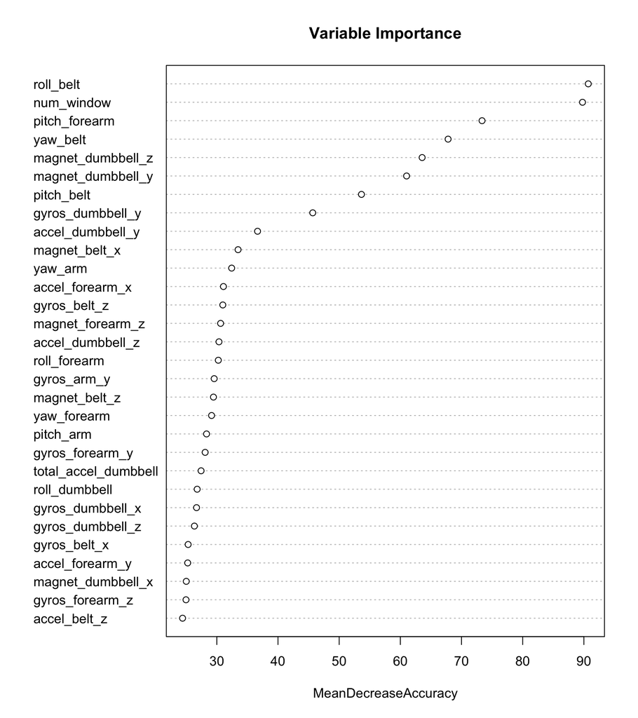

```r
varImpPlot(rfMod$finalModel, type=1, main = "Variable Importance")
```

This chart provides a visualized ranking of the relative importance of variables in the fitted model from the training set by measuring how much the accuracy of predictions would decrease if the given variable is permuted randomly. For example, from this chart we can see that `roll_belt`, `num_window`, `pitch_forearm` and `yaw_belt` are have the largest impact on the predictive accuracy of the model.

# Predicting the Testing Values

The final step is to predict the outcome from the testing data using the same random-forests model created earlier. The predicted results are:

```r
testPred <- predict(rfMod, testing)
print(xtable(data.frame(question=seq(1, 20), prediction=testPred)),
      type="html",
      include.rownames = FALSE)
```

| question | prediction |
| --- | --- |
| 1 | B |
| 2 | A |
| 3 | B |
| 4 | A |
| 5 | A |
| 6 | E |
| 7 | D |
| 8 | B |
| 9 | A |
| 10 | A |
| 11 | B |
| 12 | C |
| 13 | B |
| 14 | A |
| 15 | E |
| 16 | E |
| 17 | A |
| 18 | B |
| 19 | B |
| 20 | B |